# Yackm lab notes

Ernesto Carrella

25 February, 2015

# Convergence Speed between Marshallian and Keynesian

### Date

2015-02-08

### Background Information

Fixed wages macro runs in YACKM have a single solution and both Marshallian and Keynesian seem to get there fine.

But because they use slightly different PID setups the speed of converge looks very different from sample runs.

### References

### Purpose

Test whether the speed of convergence is the same and if not test whether equalizing PID parameters make it the same

### Hypothesis

Speed of convergence is the same or can be made so easily

### Experiment

1000 runs each, plot histograms and do simple statistical tests if necessary.

### Code used

The dart code used is `2015-02-08 convergenceSpeed.dart` in the `runs/yackm/experiments` folder.

### Results

#### Experiment 1

First I run the code without changing default, as of 2015-02-08. For Keynesian I have the following histogram:

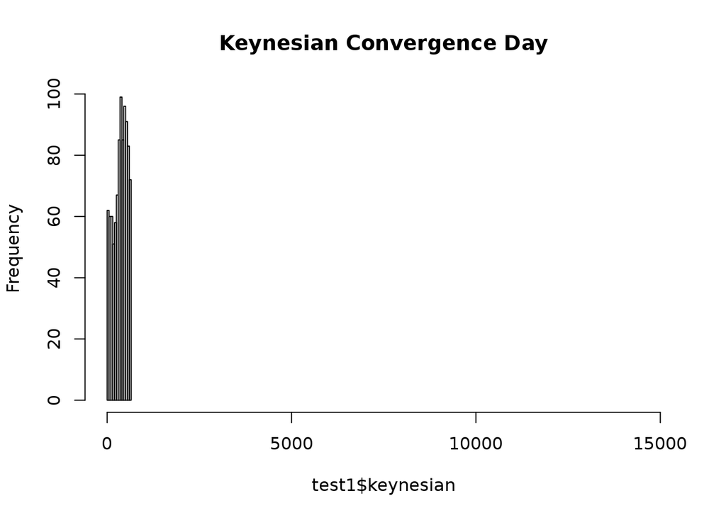

There are also 31 failures. This means the failure rate is about 3.1%

For marshallian:

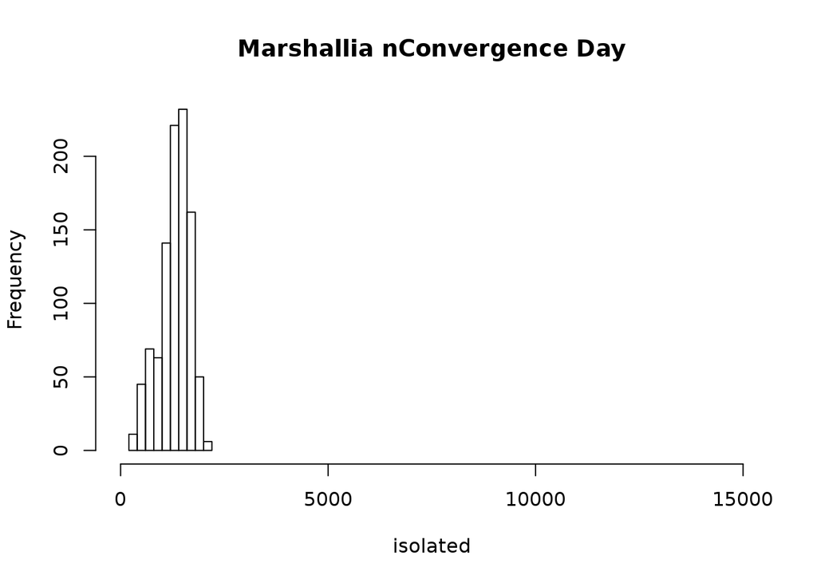

It never fails.

So with the default parameters it **Keynesian is a lot faster**.

#### Experiment 2

Changed `KEYNESIAN_QUOTA` in the scenario declaration in `model.dart`. While the default is critical inventory 100 and normal inventory 10, the keynesian quota originally went critical inventory 10, normal inventory 1.  
The unit tests ran fine, still a small % of failure for Keynesian setup though.

The results of this experiment are in `convergeSpeed2.csv` First I run the code without changing default, as of 2015-02-08. For Keynesian I have the following histogram:

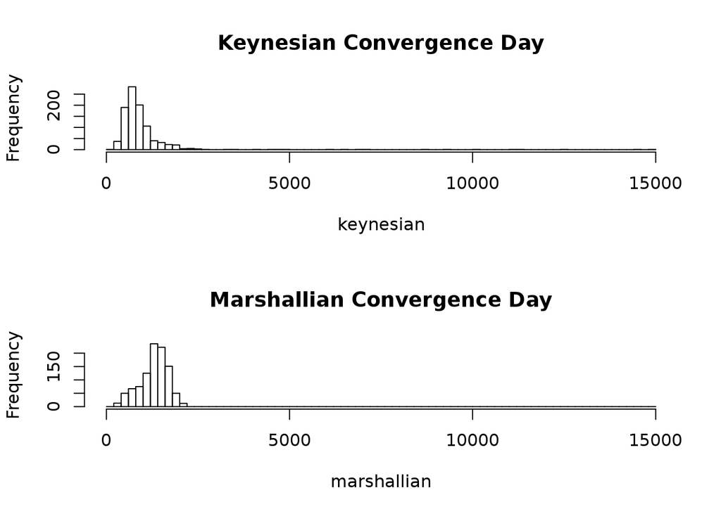

As you can see, it doesn’t matter much.

#### Experiment 3

The `PROFIT_MAXIMIZER_PRICING` uses a PI multiplier in the Keynesian scenario of about 100. Without it tests fail. There was also an initial max price parameter of 27 which I killed (doesn’t affect tests).  
What is going on is an extremely slow price adjustment:

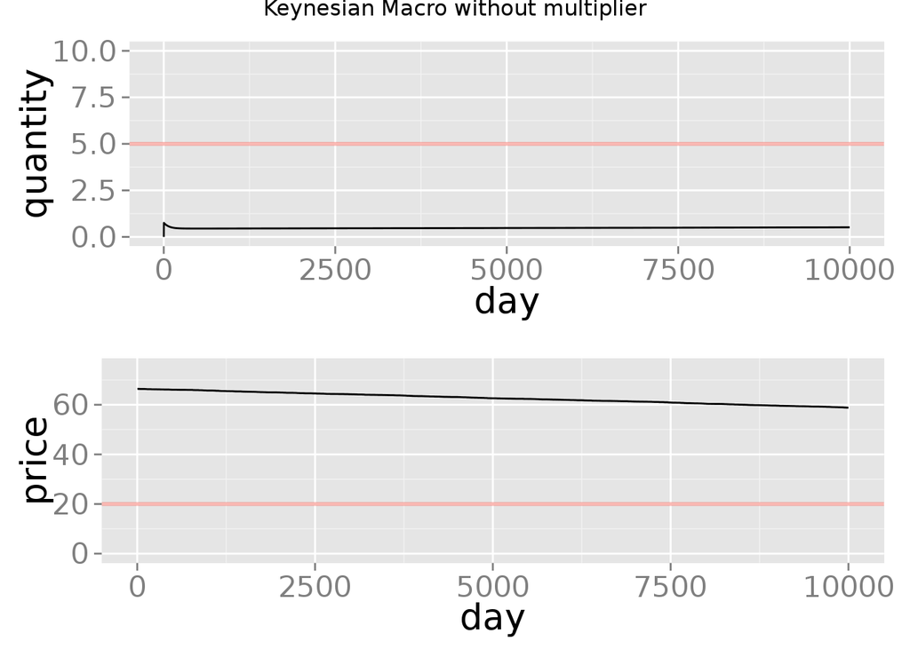

On the other hand the marshallian quota also has a PImultiplier (defaulted to 100 as well). Taking it away also make the approach much slower:

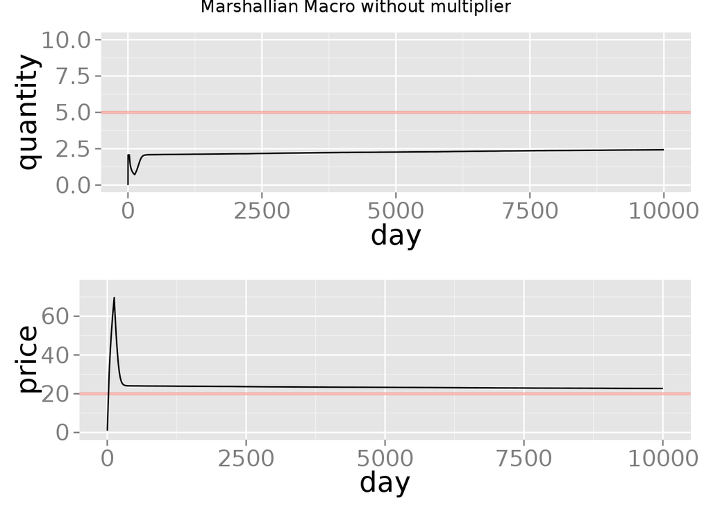

#### Experiment 4

Find the parameters for which price equal labor $p = L$ Solution is just: $\frac{2 \sqrt{\frac{4b^2}{a^2}}}{a} = \frac{4b^2}{a^2}$ Which, if we assume $a=1$ leads to $b=1$ and then: >$\begin{align*} L &= 4 \\ p &= 4 \\ Y &= 1 \end{align*}$

But something really strange happen with this setup, the PI multiplier for the Keynesian maximizer (which sets prices) is just too high so you end up with very wavy results:

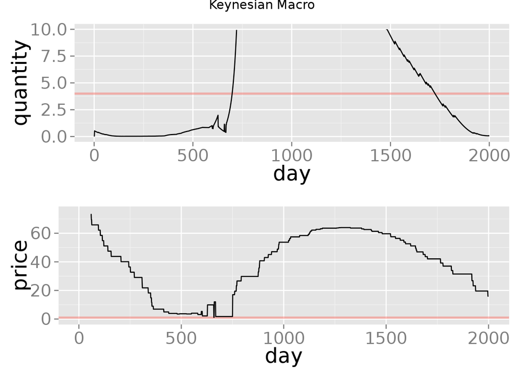

I know that’s a multiplier issue because when I lower it from 100 to 50 I get no issues. Unfortunately Marshallian multiplier at 50 means that the results are usually in time, failing tests.

Interestingly, even though the multiplier is at 50, Keynesian is still faster:

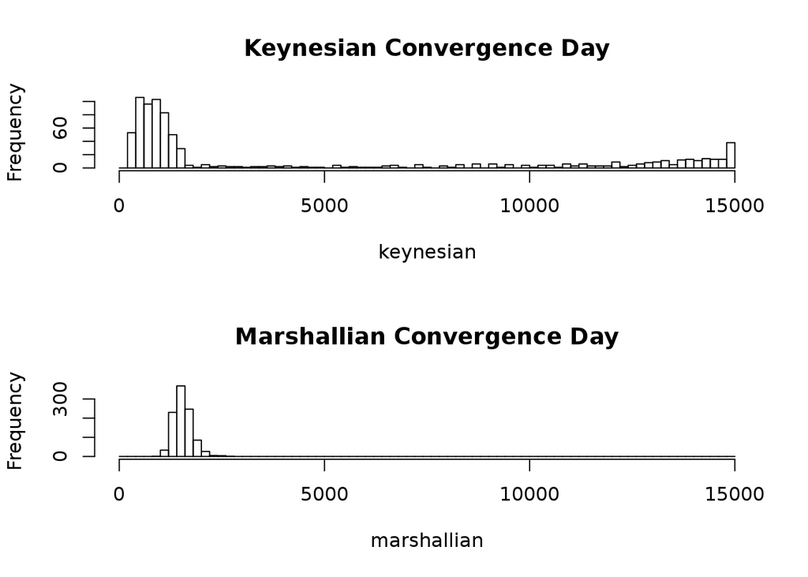

#### Experiment 6

So Marhsallian simulation uses buffer inventory while Keynesian seems to be using stockouts. I try then to run Marshall with stockout sales.

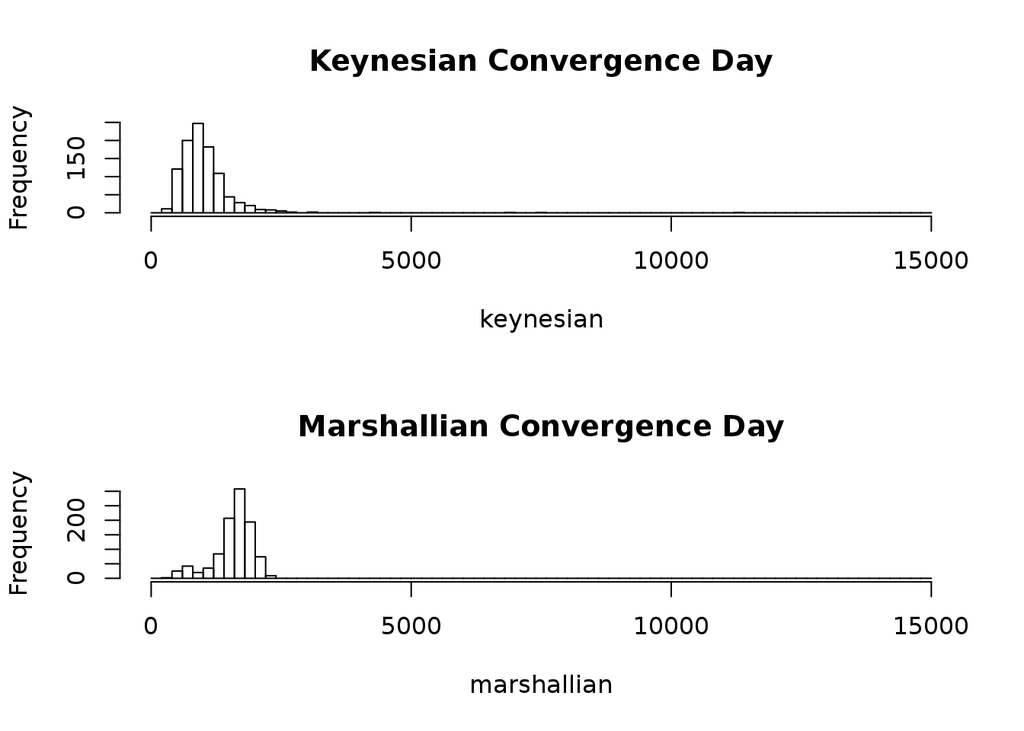

Not really any better.

#### Experiment 7

Marshallian tries to equalize MB=MC by making the sigmoid of MB/MC equals to 1. The Keynesian moves price in the opposite direction. I did so previously by doing 1/sigmoid, let me just try to do -sigmoid.

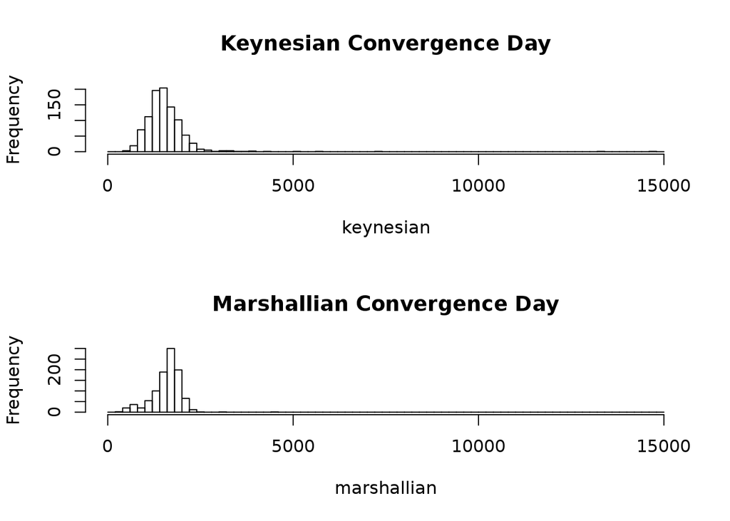

#### Experiment 8

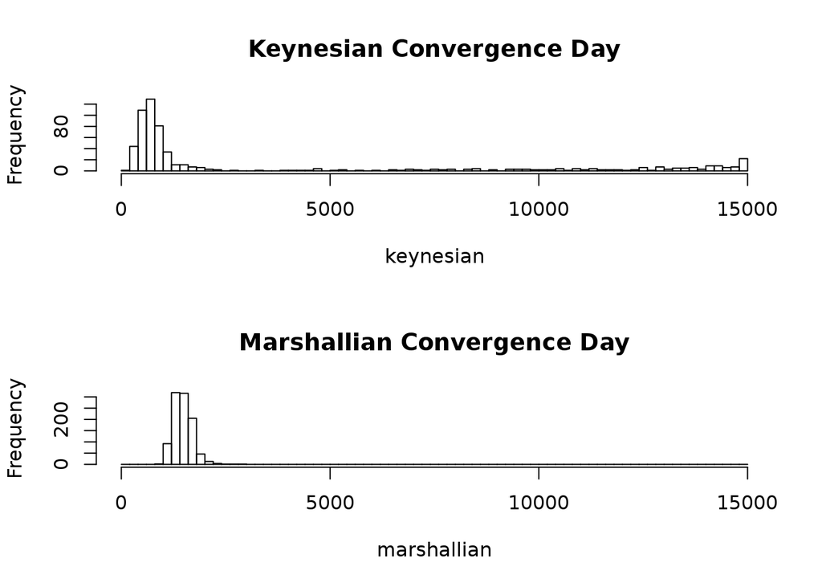

Still not good enough, also a 40% failure rate which is unacceptable

#### Experiment 9

Figuring out why it fails so damn much with Keynesian. It seems that at some point it just reaches escape velocity.

So there is a lot more outflow than inflow which pushes the labor PID to hire more workers

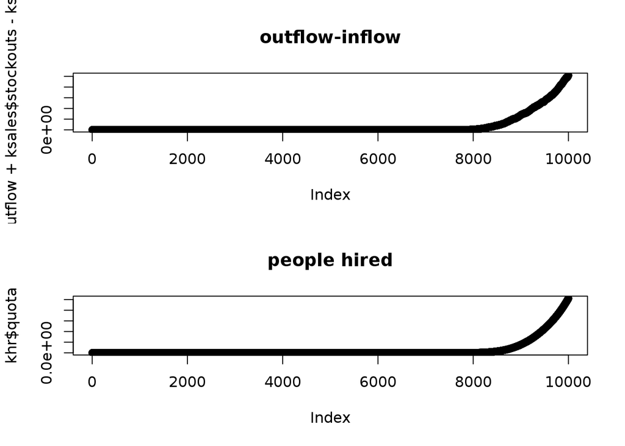

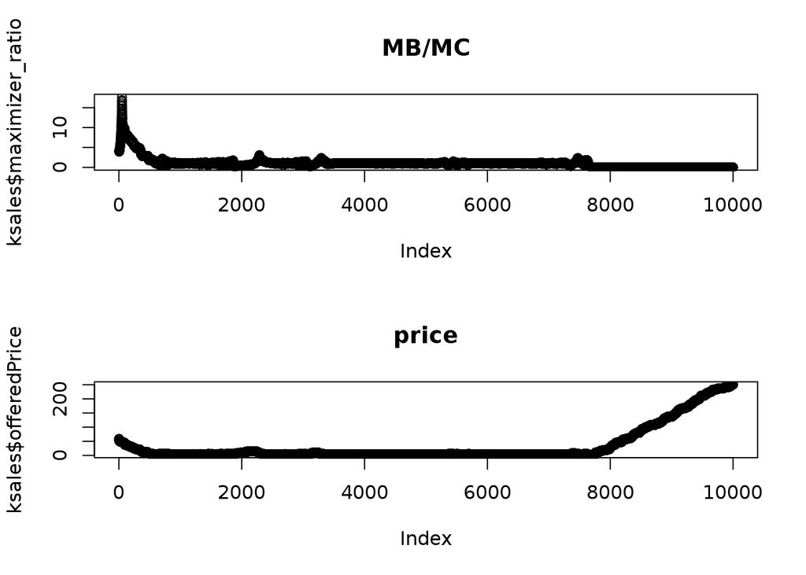

It is possible that keep hiring workers increase demand faster than it increases supply, keeping prices fixed. This is an issue because if the demand increases you answer by increasing workers in Keynesian world. Unfortunately that just starts the cycle once again.

Does it help if I increase the speed of the price pid? It would seem that increasing price faster than labor would break the error.

### Conclusion

The difference in speed doesn’t seem caused primarily by parameter differences. I would like to make sure it’s not simply a result of prices having to go all the way to 20 while labor has to go to 100 (or is it quantity going to 5?).

### Questions

- Why PI multiplier for experiment 4 needed to be lowered for Keynesian but not Marshallian (which in fact doesn’t overshoot at 100 in the same market?)
- Why does it look like price in the Keynesian mode gets adjusted far more aggressively than labor in the Marshallian one besides being run by the same sticky maximizer?
- Could it be that escape velocity is self-adjusting when dropping Q/L but not necessarilly so when increasing it?

# Effect of a demand shock

### Date

2015-02-10

### Background Information

At the present stage this seems like the most interesting question, what happens to labor, income and quantity when there is a demand shock. I know from the solution that if I lower demand by 1 the new solution is:

> $\begin{align*} L &= 64 \\ p &= 16 \\ Y &= 3 \end{align*}$

from >$\begin{align*} L &= 100 \\ p &= 20 \\ Y &= 5 \end{align*}$

And I know from tests after a shock the new equilibrium is reached (I also know that the old equilibrium is returned to if the demand shock is then removed)

### References

### Purpose

### Hypothesis

### Experiment

#### Experiment 1

Run the simulation for 20,000 days, at 10,000 the demand drops. The result is interesting for Keynesian world, but Marshallian is too slow. Marshallian:

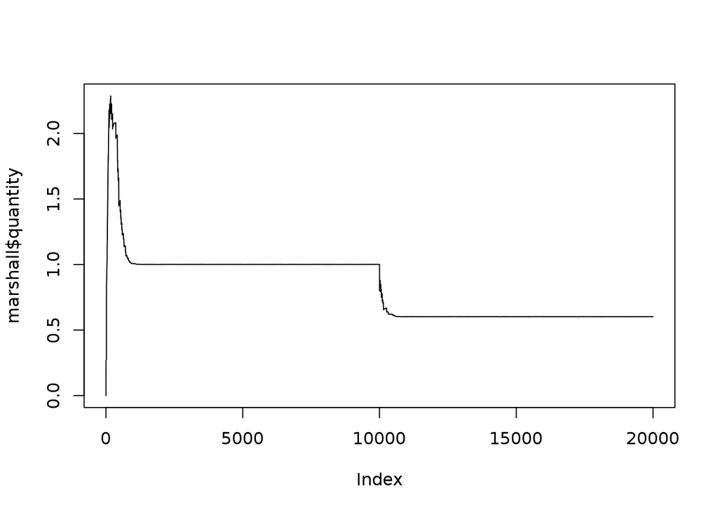

Keynesian:

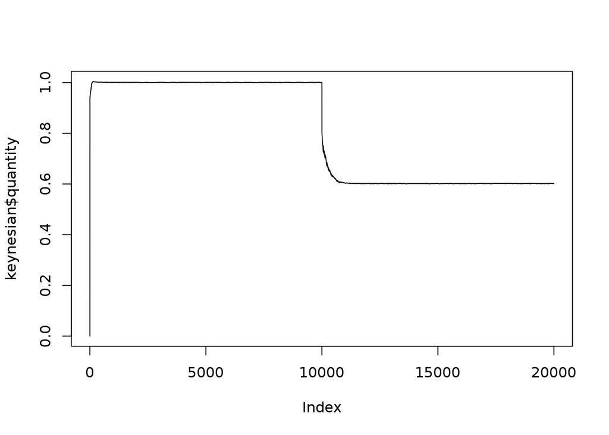

#### Experiment 2

I increase the Marshallian PI Multiplier to 1000, again this is mostly as a way to compare and contrast to similarly fast Keynesian. I get the following quantity:

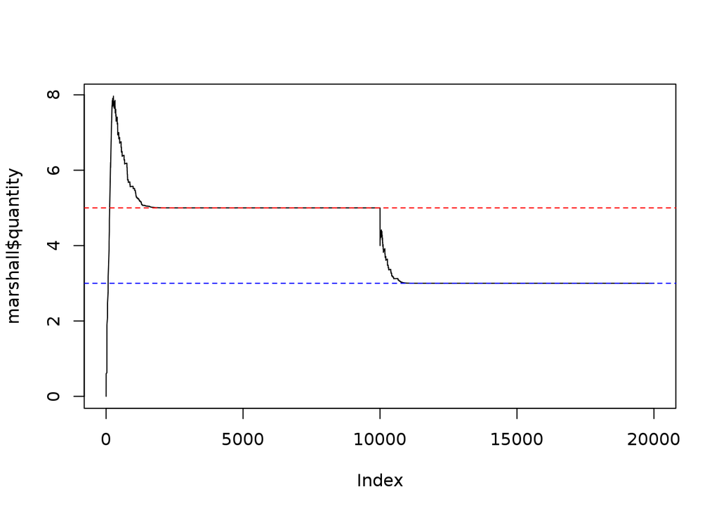

So there is no undershooting in quantity, and the overshooting at the beginning is really looks like a consequence of random initial price being so high:

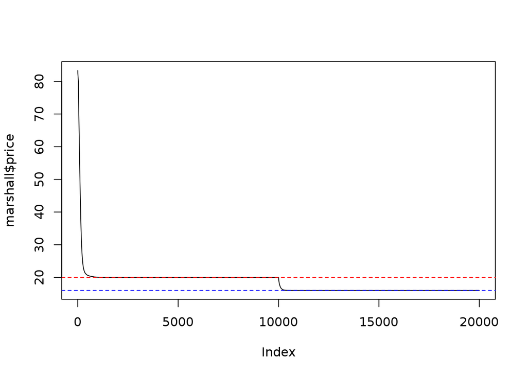

Compare this with the Keynesian world where there is undershooting.

#### Experiment 3

Keeping the Marshallian PI multiplier to 1000, here’s what happens if the shock only lasts 5000 days.

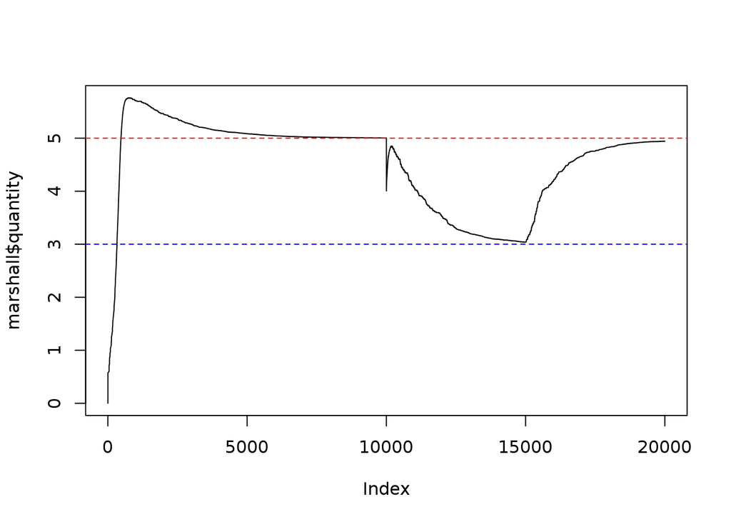

No undershooting or overshooting in the Marshallian world.

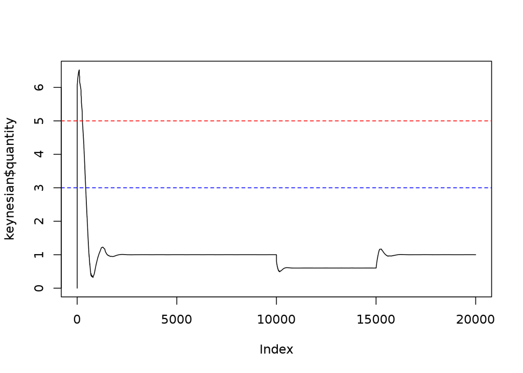

Plenty of overshooting in the Keynesian world though.

### Code used

### Results

### Conclusion

### Questions

# Convergence speed in a Micro-setting

### Date

2015-02-11

### Background Information

This follows from the previous convergence experiments in the macro-world. There seem to be too many moving parts there to really figure out what is the root cause of convergence speed. So I move to a simpler micro-example.

### References

check the experiment *Convergence Speed between Marshallian and Keynesian*

### Purpose

Simplify the scenario where Keynesian and Marshallian methods are employed to find the root cause of convergence speed divergence.

### Hypothesis

There is no difference in speed in the micro-world or if there is it is easily identifiable.

### Experiment

Does the difference in speed exist in the micro-econ world? To do I just replicate the linear demand-linear supply model that has a nice equilibrium: >$\begin{align*} L &= 50 \\ p &= 50 \\ Y &= 50 \end{align*}$ Like the micro-tests but with an infinitely elastic labor supply at $w=50$. The convergence speed should be exactly the same:

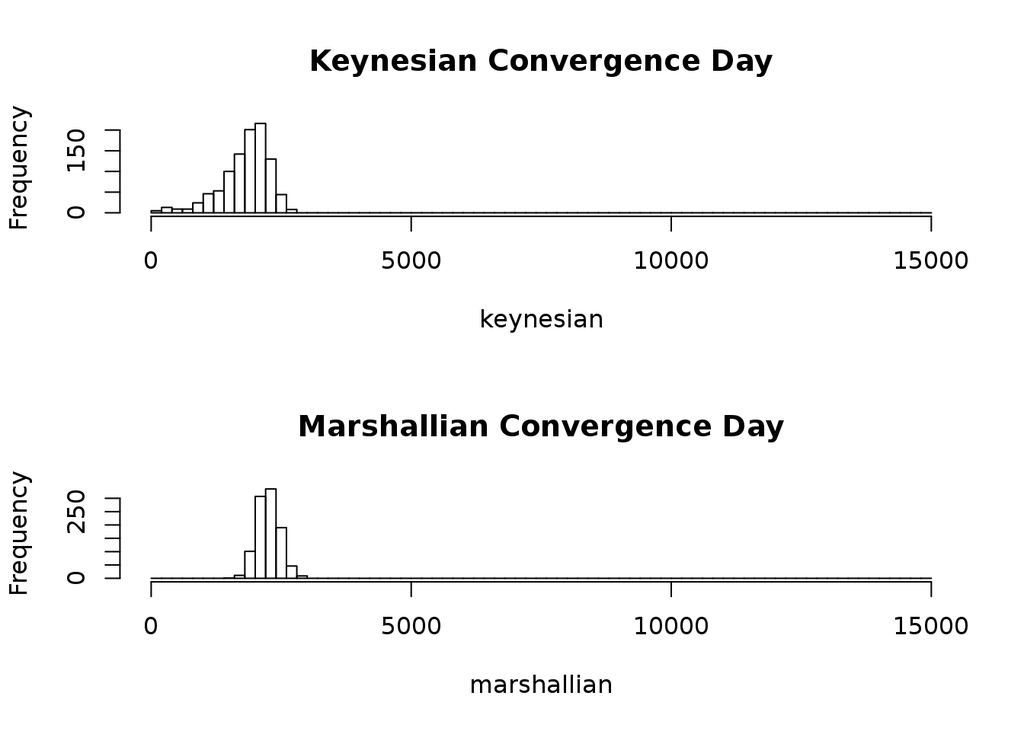

Now if I plot

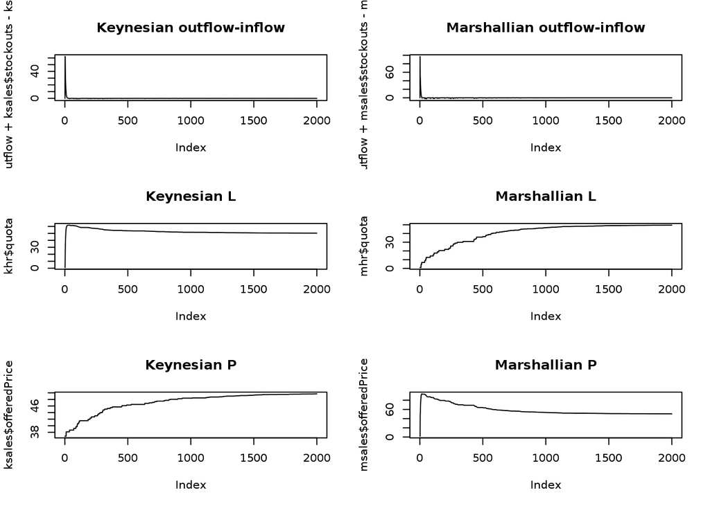

Marshallian L and Keynesian P should be run by the same kind of PI controller with the same parameters, but it looks like the Marshallian L adapts a bit faster in this case than the Keynesian P. (notice also the difference in starting point which should give advantage to the Keynesian).

If I look at the PI maximizers themselves:

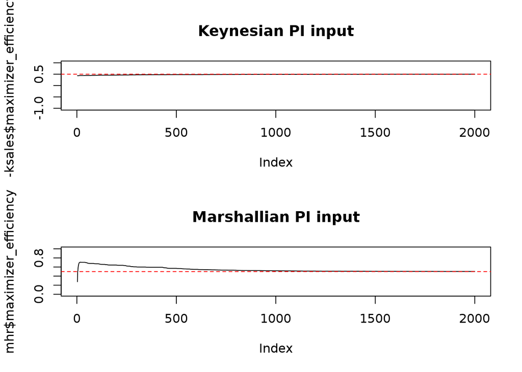

So it seems like the Marshallian PI is faster simply because we put larger inputs in it. Is it because of Keynesian starting P is usually closer to equilibrium than Marshallian starting L which is always 1? To study this I try again 1000 runs by making Marshallian L also randomly distributed. The result?

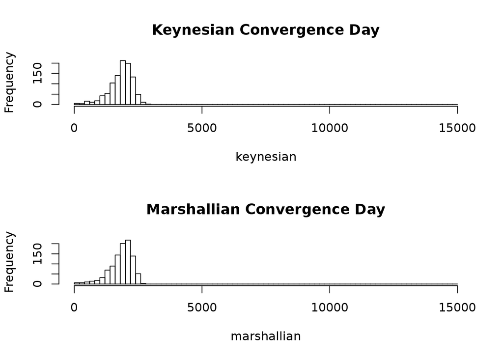

Mega-sucess! The success remain if I also randomize the initial L of the Keynesian PI (which adapts fast):

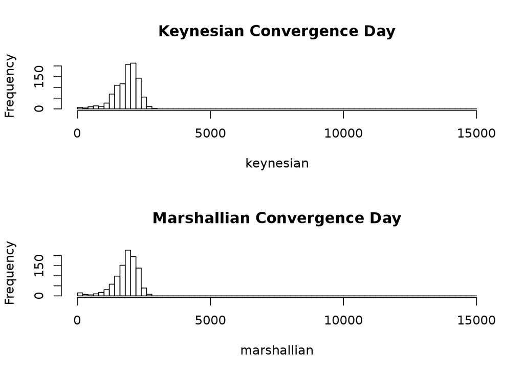

### Code used

The main code is `2015-02-11_microspeed.dartre`

### Results

- The convergence speed difference can be attributed entirely to initial conditions rather than PI parameters (at least in micro)
- Starting closer to equilibrium doesn’t mean you will achieve it quickly. Quite the opposite in this example.

### Conclusion

### Questions

- Can I generalize this back to macro?

# Convergence Speed after a drop

### Date

2015-02-11

### Background Information

I know that initial prices/targets matter when it comes to convergence speed in micro so I assume they matter in macro as well. Let’s try!

### References

### Purpose

The best way to make sure Marshallian and Keynesian agents start the same is to make them go to an equilibrium then shock the demand and see how much it takes to go to a new equilibrium.

### Hypothesis

Either there is no difference in speed or if there is it must be irreducibile (that is it is inherent in the way they adjust rather than differences in parameters)

### Experiment

Make the production equation look like this:  
$Y = 0.5 \sqrt L - 1$

This gives rises to the following macro equilibrium >$\begin{align*} L &= 16 \\ p &= 16 \\ Y &= 1 \end{align*}$

Then I lower the demand by 0.2 when shocked and I get: >$\begin{align*} L &= 10.24 \\ p &= 12.8 \\ Y &= 0.6 \end{align*}$

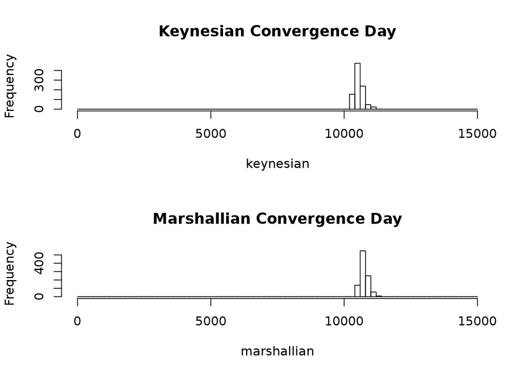

(notice that the speed difference is very different from previous experiments because $l$ and $p$ are closer)

### Code used

### Results

### Conclusion

### Questions

# Difference in shock between Keynesian macro and Marshallian macro

### Date

2015-02-24

### Background Information

The main difference between Keynesian and Marshallian world ought to be that in macro-settings Keynesian adjustments affect the demand as much as the supply; this should cause adjustment errors

### References

### Purpose

To plot the difference in adjustment dynamics

### Hypothesis

Keynesian macro should undershoot or overshoot

### Experiment

We take the expected results of “convergence speed after drop” experiment: >$\begin{align*} L &= 16 \\ p &= 16 \\ Y &= 1 \end{align*}$

And after a demand drop >$\begin{align*} L &= 10.24 \\ p &= 12.8 \\ Y &= 0.6 \end{align*}$

I run the model for 10000 days before shocking it then see what happens in the next 2000 days. The results are, fortunately, pretty much what I expected:

```
##              value time variable
## 1 1.00124960961895 9950        1
## 2 1.00124960961895 9951        1
## 3 1.00124960961895 9952        1
## 4 1.00124960961895 9953        1
## 5 1.00124960961895 9954        1
## 6 1.00124960961895 9955        1
```

```
##     value time variable
## 1 1.00125 9950        1
## 2 1.00125 9951        1
## 3 1.00125 9952        1
## 4 1.00125 9953        1
## 5 1.00125 9954        1
## 6 1.00125 9955        1
```

```
##              value time variable
## 1 1.00124960961895 9950        1
## 2 1.00124960961895 9951        1
## 3 1.00124960961895 9952        1
## 4 1.00124960961895 9953        1
## 5 1.00124960961895 9954        1
## 6 1.00062490237426 9955        1
```

```
##      value time variable
## 1 1.001250 9950        1
## 2 1.001250 9951        1
## 3 1.001250 9952        1
## 4 1.001250 9953        1
## 5 1.001250 9954        1
## 6 1.000625 9955        1
```

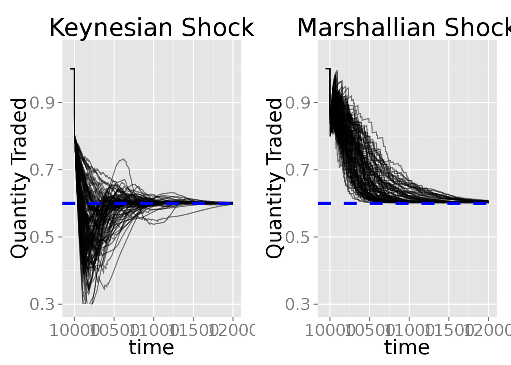

Notice how Marshallian adjust to demand shock. The $y$ is traded quantity so when there is a demand shock and labor takes time to adjust the marshallian firm lowers prices which pushes quantity traded back up, but eventually production starts dropping as it is unprofitable and we go back to equilibrium.

### Code used

The code is in `runs/experiments/2015-02-23_overshoot.dart` . The results are in ```docs/yackm/rawdata/1000macro 2015-02-24````, together with a copy of the input json used

### Results

Keynesian macro has overshooting and undershooting while marshallian world has none

### Conclusion

### Questions

# Increasing Flexibility Before the crisis

### Date

2015-02-24

### Background Information

From the previous experiment we know that a shock in the Keynesian world might cause overshooting and undershooting. Time to see how a more aggressive adjustment policies affects it

### References

### Purpose

To see whether the increasing P and I parameters bring faster changes or just bigger overshooting-undershooting

### Hypothesis

Increasing P and I parameters make matter worse

### Experiment

Same setup as usual:  
>$\begin{align*} L &= 16 \\ p &= 16 \\ Y &= 1 \end{align*}$  
that gets shocked to:  
>$\begin{align*} L &= 10.24 \\ p &= 12.8 \\ Y &= 0.6 \end{align*}$

This time when the shock happens (at day 10,000) we also add .2 to the P and I parameters of the HR quota strategy, making it faster. I run 100 experiments with and without the speed adjustment, keeping seeds the same for more accurate comparison.

```
##              value time variable
## 1 1.00062490237426 9950        1
## 2 1.00062490237426 9951        1
## 3 1.00062490237426 9952        1
## 4 1.00062490237426 9953        1
## 5 1.00062490237426 9954        1
## 6 1.00062490237426 9955        1
```

```
##      value time variable
## 1 1.000625 9950        1
## 2 1.000625 9951        1
## 3 1.000625 9952        1
## 4 1.000625 9953        1
## 5 1.000625 9954        1
## 6 1.000625 9955        1
```

```
##              value time variable
## 1 1.00062490237426 9950        1
## 2 1.00062490237426 9951        1
## 3 1.00062490237426 9952        1
## 4 1.00062490237426 9953        1
## 5 1.00062490237426 9954        1
## 6 1.00062490237426 9955        1
```

```
##      value time variable
## 1 1.000625 9950        1
## 2 1.000625 9951        1
## 3 1.000625 9952        1
## 4 1.000625 9953        1
## 5 1.000625 9954        1
## 6 1.000625 9955        1
```

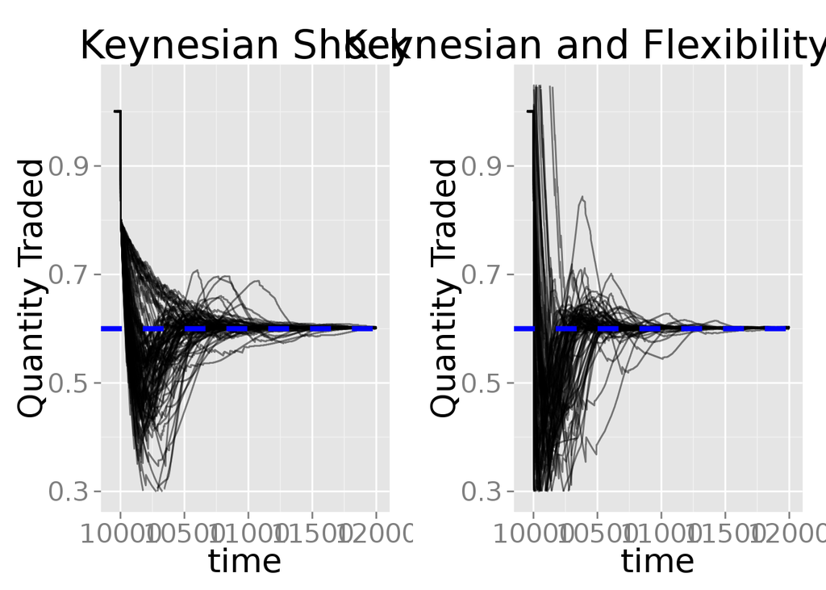

### Code used

The code used is in `2015-02-24_flexibility.dart` in the `\lib\runs\experiments`. The output is in `docs/yackm/rawdata/pi speed shock2015-02-24 13:41:17.795`

### Results

The shock is worse, but i need to devise a couple of metrics to establish its size. Also, it might be that there is an “optimal” speed rather than “faster is worse”.

### Conclusion

### Questions

- Can I devise a good metric for overshooting-understhooting?
- Can I do these experiments for multiple speed shocks and see which one gives me the optimal speed parameter?